# Linear Regression: Model Specification, Comparison, and Interpretation

- Show All Code
- Hide All Code
- View Source

Author

Alana Graham

For Lab 3, I have applied linear regression to investigate the factors associated with employees’ ratings of their workplace using the built-in R dataset “attitude”. Specifically, I am examining multiple competing models with departmental handling of employee complaints, opportunity to learn, and pay increases as predictors of overall workplace ratings.

## Descriptive Statistics

Here is a formatted table reporting the mean, standard deviation, minimum, and maximum for each analysis variable.

```r
## Setup
library(carData)
library(dplyr)
library(tidyr)
library(ggplot2)
library(broom)
library(performance)
library(gt)

attitude.df <- data("attitude")

workplace.rating.df <- attitude |>
  select(rating, complaints, learning, raises)

#Exploring the data
descriptives <- workplace.rating.df |>
  summarise(across(
      c(rating, complaints, learning, raises),
      list(mean = mean, sd = sd, min = min, max = max))) |>
  pivot_longer(
    everything(),
    names_to = c("variable", ".value"),
    names_sep = "_")

descriptives |>
  gt() |>
  fmt_number(columns = where(is.numeric), decimals = 2)
```

| variable | mean | sd | min | max |
| --- | --- | --- | --- | --- |
| rating | 64.63 | 12.17 | 40.00 | 85.00 |
| complaints | 66.60 | 13.31 | 37.00 | 90.00 |
| learning | 56.37 | 11.74 | 34.00 | 75.00 |
| raises | 64.63 | 10.40 | 43.00 | 88.00 |

Here is a histogram of overall workplace ratings, with an overlaid density curve.

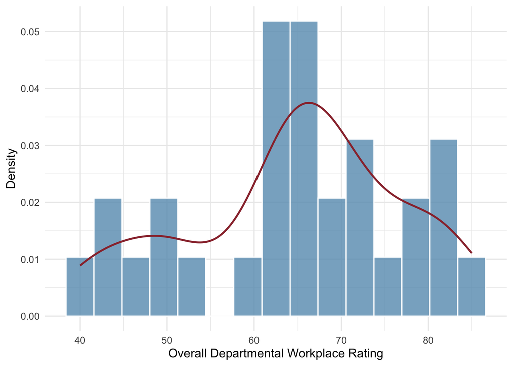

```r
ggplot(workplace.rating.df, aes(x = rating)) +
  geom_histogram(
    aes(y = after_stat(density)),
    bins = 15,
    fill = "#669BBC",
    color = "white",
    alpha = 0.8) +
  geom_density(
    linewidth = 0.9,
    color = "#9A3038") +
  labs(x = "Overall Departmental Workplace Rating",
    y = "Density") +
  theme_minimal(base_size = 12)
```